# Homework 02

## Question 1: Training and test error under a fixed design

### a. Simulation

I generate `X_all` only once. Within each repetition, the same training and test responses are used for all 21 nested models, so differences across values of $m$ are not caused by regenerating the data.

**Show the Python code**

```python
import numpy as np
import pandas as pd
import matplotlib.pyplot as plt

rng1 = np.random.default_rng(43202)
n1, p1, R1 = 100, 20, 200

X1 = rng1.standard_normal((n1, p1))
beta1 = 0.4 ** np.sqrt(np.arange(1, p1 + 1))
mu1 = X1 @ beta1

# Store an orthonormal basis for every candidate model.  Projection onto
# the model space is then Q @ Q.T @ y.
bases1 = []
for m in range(p1 + 1):
    design = np.c_[np.ones(n1), X1[:, :m]]
    bases1.append(np.linalg.qr(design, mode="reduced")[0])

train1 = np.zeros((R1, p1 + 1))
test1 = np.zeros((R1, p1 + 1))

for r in range(R1):
    y = mu1 + rng1.standard_normal(n1)
    y_new = mu1 + rng1.standard_normal(n1)
    for m, Q in enumerate(bases1):
        fitted = Q @ (Q.T @ y)
        train1[r, m] = np.mean((y - fitted) ** 2)
        test1[r, m] = np.mean((y_new - fitted) ** 2)

avg_train1 = train1.mean(axis=0)
avg_test1 = test1.mean(axis=0)

# Check every adjacent pair in every repetition.
largest_training_increase = np.diff(train1, axis=1).max()
training_never_increases = largest_training_increase <= 1e-10

print("Training MSE never increases:", training_never_increases)
print("Largest numerical increase:", largest_training_increase)
```

```
Training MSE never increases: True
Largest numerical increase: -1.6375264477730411e-09
```

The check returns `True`. This is also expected algebraically: when a predictor is added, the old fitted-value space is contained in the new one, so least squares can always reproduce the old fit and possibly improve it.

### b. Conditional expectations

**Show the Python code**

|  | m | average training MSE | expected training MSE | average test MSE | expected test MSE |
| --- | --- | --- | --- | --- | --- |
| 0 | 0 | 1.3220 | 1.3078 | 1.3416 | 1.3278 |
| 1 | 1 | 1.1815 | 1.1704 | 1.2208 | 1.2104 |
| 2 | 2 | 1.1124 | 1.1024 | 1.1708 | 1.1624 |
| 3 | 3 | 1.0842 | 1.0727 | 1.1577 | 1.1527 |
| 4 | 4 | 1.0319 | 1.0216 | 1.1237 | 1.1216 |
| 5 | 5 | 0.9976 | 0.9894 | 1.1107 | 1.1094 |
| 6 | 6 | 0.9667 | 0.9627 | 1.1050 | 1.1027 |
| 7 | 7 | 0.9457 | 0.9427 | 1.1027 | 1.1027 |
| 8 | 8 | 0.9270 | 0.9254 | 1.1045 | 1.1054 |
| 9 | 9 | 0.9105 | 0.9125 | 1.1153 | 1.1125 |
| 10 | 10 | 0.8960 | 0.8980 | 1.1218 | 1.1180 |
| 11 | 11 | 0.8844 | 0.8856 | 1.1287 | 1.1256 |
| 12 | 12 | 0.8743 | 0.8744 | 1.1355 | 1.1344 |
| 13 | 13 | 0.8634 | 0.8634 | 1.1436 | 1.1434 |
| 14 | 14 | 0.8531 | 0.8526 | 1.1534 | 1.1526 |
| 15 | 15 | 0.8446 | 0.8419 | 1.1605 | 1.1619 |
| 16 | 16 | 0.8322 | 0.8313 | 1.1722 | 1.1713 |
| 17 | 17 | 0.8211 | 0.8208 | 1.1836 | 1.1808 |
| 18 | 18 | 0.8112 | 0.8104 | 1.1938 | 1.1904 |
| 19 | 19 | 0.8009 | 0.8002 | 1.2021 | 1.2002 |
| 20 | 20 | 0.7889 | 0.7900 | 1.2119 | 1.2100 |

```
Largest |simulation - theory| for training: 0.014241581251963842
Largest |simulation - theory| for test: 0.013791519284938047
m minimizing average test MSE: 7
m minimizing expected test MSE: 7
```

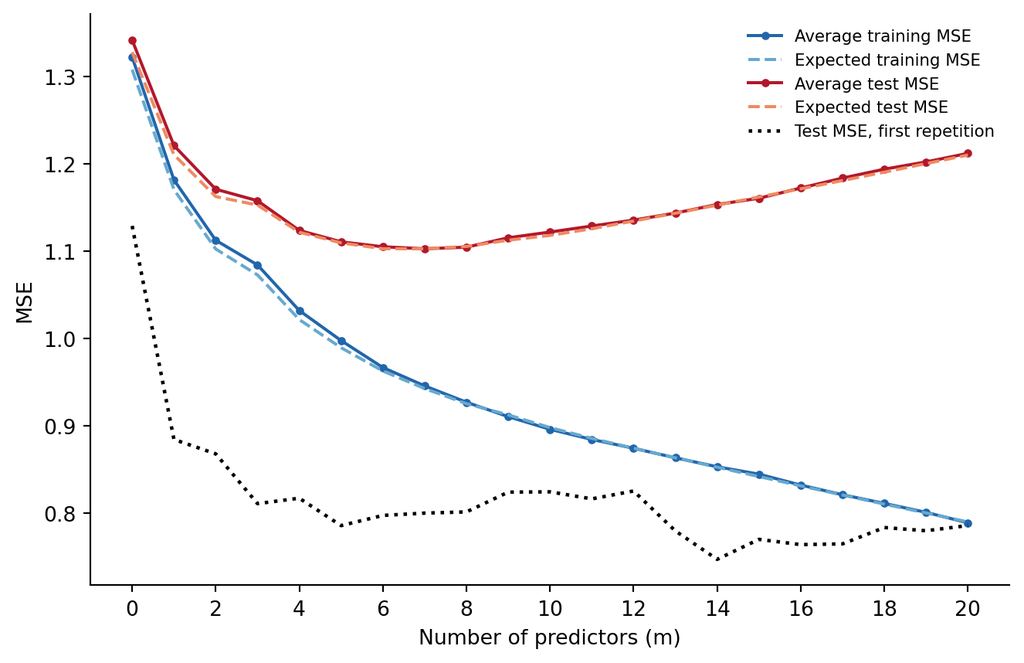

```python
bias_mse1 = np.zeros(p1 + 1)
for m, Q in enumerate(bases1):
    projected_mu = Q @ (Q.T @ mu1)
    bias_mse1[m] = np.mean((mu1 - projected_mu) ** 2)

m_grid1 = np.arange(p1 + 1)
k_grid1 = m_grid1 + 1  # intercept plus m slopes
expected_train1 = bias_mse1 + 1 - k_grid1 / n1
expected_test1 = bias_mse1 + 1 + k_grid1 / n1

summary1 = pd.DataFrame({
    "m": m_grid1,
    "average training MSE": avg_train1,
    "expected training MSE": expected_train1,
    "average test MSE": avg_test1,
    "expected test MSE": expected_test1,
})
display(summary1.round(4))

print("Largest |simulation - theory| for training:",
      np.max(np.abs(avg_train1 - expected_train1)))
print("Largest |simulation - theory| for test:",
      np.max(np.abs(avg_test1 - expected_test1)))
print("m minimizing average test MSE:", int(np.argmin(avg_test1)))
print("m minimizing expected test MSE:", int(np.argmin(expected_test1)))

fig, ax = plt.subplots(figsize=(8, 5))
ax.plot(m_grid1, avg_train1, "o-", ms=3, color="#2166ac",
        label="Average training MSE")
ax.plot(m_grid1, expected_train1, "--", color="#67a9cf",
        label="Expected training MSE")
ax.plot(m_grid1, avg_test1, "o-", ms=3, color="#b2182b",
        label="Average test MSE")
ax.plot(m_grid1, expected_test1, "--", color="#ef8a62",
        label="Expected test MSE")
ax.plot(m_grid1, test1[0], ":", lw=1.7, color="black",
        label="Test MSE, first repetition")
ax.set(xlabel="Number of predictors (m)", ylabel="MSE",
       xticks=np.arange(0, p1 + 1, 2))
ax.spines[["top", "right"]].set_visible(False)
ax.legend(frameon=False, fontsize=8)
plt.show()
```

The simulated averages lie close to the conditional expectations. Their differences are ordinary Monte Carlo error from using 200 repetitions rather than infinitely many.

### c. Interpretation

The curve from one repetition is jagged because it contains the particular random training and test errors from that repetition. Averaging 200 independent repetitions cancels much of this noise and reveals the underlying expected-error curve.

Expected test MSE is

$$\frac{B_m^2}{n}+1+\frac{m+1}{n}.$$

Adding variables tends to reduce the approximation-bias term $B_m^2/n$, but it increases the estimation-variance term $(m+1)/n$. Test error balances these effects. Training MSE instead has $-(m+1)/n$; it rewards the ability to fit training noise and therefore cannot, by itself, provide an honest choice of $m$.

## Question 2: Prediction error at one target point

### a. Theoretical error

At the target point,

$$\mu_0=\mathbf x_0^{\mathsf T}\boldsymbol\beta
=0(0.5)+1(0.5)+0(0.5)+0(0.5)+1(0.5)+0(0.5)=1.$$

The omitted-variable contribution is the sum of $x_{0j}\beta_j$ over predictors not yet included. Its square is the squared bias. The variance starts with $1/n$ for the estimated intercept and gains $x_{0j}^2/n$ for each fitted slope. Orthogonality makes these coefficient-estimation contributions additive.

**Show the Python code**

```python
rng2 = np.random.default_rng(43203)
n2, p2, R2 = 100, 6, 200
rows = np.arange(1, n2 + 1)[:, None]
cols = np.arange(1, p2 + 1)[None, :]
X2 = np.sqrt(2) * np.cos(np.pi * cols * (rows - 0.5) / n2)

beta2 = np.full(p2, 0.5)
x0 = np.array([0, 1, 0, 0, 1, 0], dtype=float)
mu2 = X2 @ beta2
mu0 = float(x0 @ beta2)

m_grid2 = np.arange(p2 + 1)
squared_bias2 = np.zeros(p2 + 1)
variance2 = np.zeros(p2 + 1)

for m in m_grid2:
    squared_bias2[m] = (x0[m:] @ beta2[m:]) ** 2
    variance2[m] = (1 + x0[:m] @ x0[:m]) / n2

expected2 = squared_bias2 + variance2
theory_table2 = pd.DataFrame({
    "m": m_grid2,
    "squared bias": squared_bias2,
    "estimation variance": variance2,
    "expected squared error": expected2,
})
display(theory_table2)
```

|  | m | squared bias | estimation variance | expected squared error |
| --- | --- | --- | --- | --- |
| 0 | 0 | 1.00 | 0.01 | 1.01 |
| 1 | 1 | 1.00 | 0.01 | 1.01 |
| 2 | 2 | 0.25 | 0.02 | 0.27 |
| 3 | 3 | 0.25 | 0.02 | 0.27 |
| 4 | 4 | 0.25 | 0.02 | 0.27 |
| 5 | 5 | 0.00 | 0.03 | 0.03 |
| 6 | 6 | 0.00 | 0.03 | 0.03 |

Prediction error at the specified target point.

The expected error changes when $m$ reaches 2 and 5. It is unchanged from $m=0$ to 1, from $m=2$ through 4, and from $m=5$ to 6. This happens because only $x_{02}$ and $x_{05}$ are nonzero.

### b. Simulation

**Show the Python code**

|  | m | simulation average | theoretical expectation |
| --- | --- | --- | --- |
| 0 | 0 | 0.9839 | 1.01 |
| 1 | 1 | 0.9839 | 1.01 |
| 2 | 2 | 0.2464 | 0.27 |
| 3 | 3 | 0.2464 | 0.27 |
| 4 | 4 | 0.2464 | 0.27 |
| 5 | 5 | 0.0237 | 0.03 |
| 6 | 6 | 0.0237 | 0.03 |

```
Smallest theoretical minimizer: 5
```

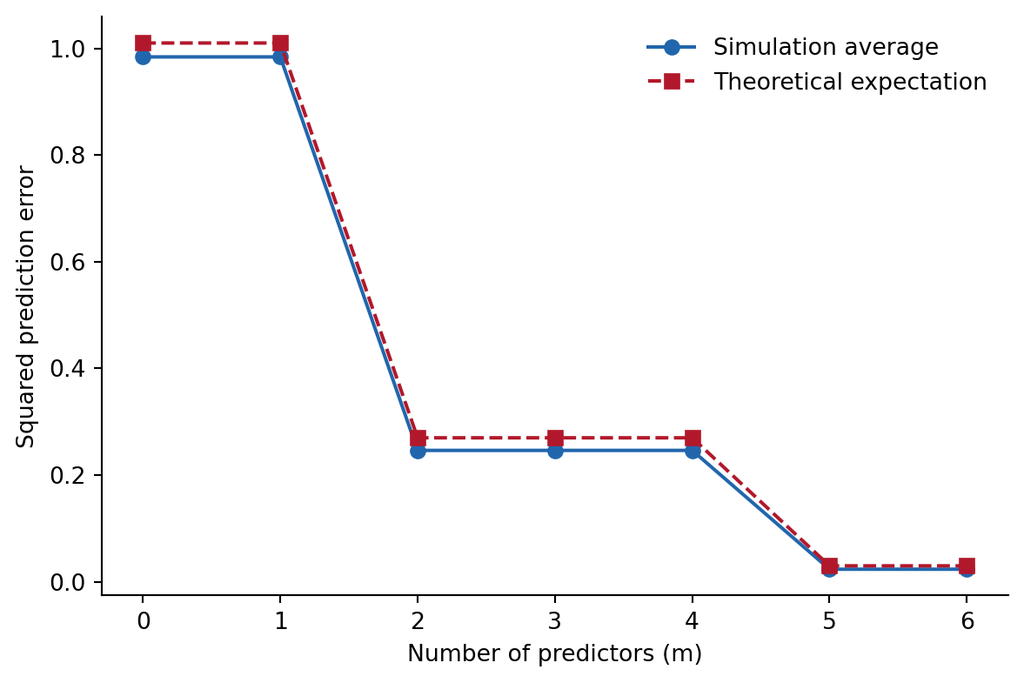

```python
target_error2 = np.zeros((R2, p2 + 1))

for r in range(R2):
    y = mu2 + rng2.standard_normal(n2)
    for m in m_grid2:
        design = np.c_[np.ones(n2), X2[:, :m]]
        coef = np.linalg.lstsq(design, y, rcond=None)[0]
        target_row = np.r_[1.0, x0[:m]]
        prediction = target_row @ coef
        target_error2[r, m] = (prediction - mu0) ** 2

average_target_error2 = target_error2.mean(axis=0)
comparison2 = pd.DataFrame({
    "m": m_grid2,
    "simulation average": average_target_error2,
    "theoretical expectation": expected2,
})
display(comparison2.round(4))
print("Smallest theoretical minimizer:", int(np.argmin(expected2)))

fig, ax = plt.subplots(figsize=(7, 4.5))
ax.plot(m_grid2, average_target_error2, "o-", color="#2166ac",
        label="Simulation average")
ax.plot(m_grid2, expected2, "s--", color="#b2182b",
        label="Theoretical expectation")
ax.set(xlabel="Number of predictors (m)",
       ylabel="Squared prediction error", xticks=m_grid2)
ax.spines[["top", "right"]].set_visible(False)
ax.legend(frameon=False)
plt.show()
```

The smallest minimizing value is $m=5$. Including predictor 6 does not change the theoretical error at this target.

### c. Target-specific versus average prediction

Although every coefficient is nonzero, the target mean multiplies coefficients 1, 3, 4, and 6 by zero. Thus only predictors 2 and 5 directly affect $\mu_0$. In contrast, the test MSE in Question 1 averages errors over all design rows. A predictor that is zero at one target can still vary across those rows and matter for average prediction performance.

## Question 3: The optimism correction

Let $\mathbf A=\mathbf I_n-\mathbf H$. Because $\mathbf H$ is symmetric and idempotent, so is $\mathbf A$, and

$$\operatorname{tr}(\mathbf A)=n-(p+1).$$

### a. Expected training and test MSE

For training error,

$$\mathbf y-\mathbf H\mathbf y
=\mathbf A\boldsymbol\mu+\mathbf A\boldsymbol\epsilon.$$

The cross term has conditional expectation zero. Therefore,

$$\begin{aligned}
E\!\left(\|\mathbf y-\mathbf H\mathbf y\|^2\mid\mathbf X\right)
&=\|\mathbf A\boldsymbol\mu\|^2
+E(\boldsymbol\epsilon^{\mathsf T}\mathbf A^{\mathsf T}\mathbf A
\boldsymbol\epsilon\mid\mathbf X)\\
&=B^2+\sigma^2\operatorname{tr}(\mathbf A)\\
&=B^2+\sigma^2[n-(p+1)].
\end{aligned}$$

After division by $n$,

$$E(\operatorname{MSE}_{\mathrm{train}}\mid\mathbf X)
=\frac{B^2}{n}+\sigma^2\left(1-\frac{p+1}{n}\right).$$

For an independent test response,

$$\mathbf y^*-\mathbf H\mathbf y
=\mathbf A\boldsymbol\mu+\boldsymbol\epsilon^*-
\mathbf H\boldsymbol\epsilon.$$

Consequently,

$$E(\operatorname{MSE}_{\mathrm{test}}\mid\mathbf X)
=\frac{B^2}{n}+\sigma^2\left(1+\frac{p+1}{n}\right).$$

### b. Optimism and numerical example

Subtracting the two expectations cancels the bias and irreducible-error terms:

$$E(\operatorname{MSE}_{\mathrm{test}}-
\operatorname{MSE}_{\mathrm{train}}\mid\mathbf X)
=\frac{2(p+1)\sigma^2}{n}.$$

Here $p+1=5$, so

$$E(\operatorname{MSE}_{\mathrm{train}}\mid\mathbf X)
=0.04+1-\frac{5}{120}=0.998333,$$

$$E(\operatorname{MSE}_{\mathrm{test}}\mid\mathbf X)
=0.04+1+\frac{5}{120}=1.081667,$$

and the expected optimism is

$$\frac{10}{120}=0.083333.$$

These statements concern expectations. For one realized training/test pair, random noise can make the observed test MSE smaller than the observed training MSE.

### c. Corrected test MSE and Mallows’ $C_p$

The corrected estimate is

$$\widehat{\operatorname{MSE}}_{\mathrm{test}}
=\frac{116.4+2(5)(0.96)}{120}
=\frac{126}{120}=1.05.$$

Also,

$$C_p=\frac{116.4}{0.96}-120+2(5)=11.25.$$

Rearranging the definition of $C_p$ gives

$$\widehat\sigma^2(C_p+n)
=\operatorname{RSS}+2(p+1)\widehat\sigma^2,$$

and hence

$$\widehat{\operatorname{MSE}}_{\mathrm{test}}
=\frac{\widehat\sigma^2}{n}(C_p+n).$$

When $n$ and $\widehat\sigma^2$ are shared by all candidates, the right-hand side is a positive affine transformation of $C_p$. Therefore the two criteria have the same minimizer.

## Question 4: Comparing Mallows’ $C_p$, AIC, and BIC

### a–b. Model fits and criteria

**Show the Python code**

```python
from pathlib import Path
import numpy as np
import pandas as pd

data4 = pd.read_csv(Path("data") / "diabetes.csv").iloc[:370]
y4 = data4["y"].to_numpy()
n4 = len(data4)

predictors4 = {
    "Model A": ["bmi", "bp", "s5", "sex", "s1", "s2", "s4"],
    "Model B": ["bmi", "bp", "s5", "sex", "s1", "s2", "s4", "s6"],
    "Full": ["age", "sex", "bmi", "bp", "s1", "s2", "s3", "s4", "s5", "s6"],
}

def residual_sum_of_squares(columns):
    design = np.c_[np.ones(n4), data4[columns].to_numpy()]
    coefficients = np.linalg.lstsq(design, y4, rcond=None)[0]
    residuals = y4 - design @ coefficients
    return float(residuals @ residuals)

rss4 = {name: residual_sum_of_squares(cols)
        for name, cols in predictors4.items()}
p_count4 = {name: len(cols) for name, cols in predictors4.items()}

full_df4 = n4 - (p_count4["Full"] + 1)
sigma2_hat4 = rss4["Full"] / full_df4

rows4 = []
for name in ["Model A", "Model B"]:
    p = p_count4[name]
    rss = rss4[name]
    rows4.append({
        "model": name,
        "p": p,
        "RSS": rss,
        "Cp": rss / sigma2_hat4 - n4 + 2 * (p + 1),
        "reduced AIC": n4 * np.log(rss / n4) + 2 * (p + 1),
        "reduced BIC": n4 * np.log(rss / n4) + (p + 1) * np.log(n4),
    })

criteria4 = pd.DataFrame(rows4)
print("Full-model RSS:", rss4["Full"])
print("Full-model residual degrees of freedom:", full_df4)
print("Common variance estimate:", sigma2_hat4)
display(criteria4.round(3))

for criterion in ["Cp", "reduced AIC", "reduced BIC"]:
    winner = criteria4.loc[criteria4[criterion].idxmin(), "model"]
    print(f"{criterion} selects {winner}")
```

```
Full-model RSS: 1089451.7212190419
Full-model residual degrees of freedom: 359
Common variance estimate: 3034.6844602201722
```

|  | model | p | RSS | Cp | reduced AIC | reduced BIC |
| --- | --- | --- | --- | --- | --- | --- |
| 0 | Model A | 7 | 1098908.566 | 8.116 | 2974.640 | 3005.948 |
| 1 | Model B | 8 | 1089717.057 | 7.087 | 2973.532 | 3008.754 |

```
Cp selects Model B
reduced AIC selects Model B
reduced BIC selects Model A
```

The full model has 10 predictors, 11 fitted coefficients, and therefore $370-11=359$ residual degrees of freedom. The displayed calculation gives $\widehat\sigma^2\approx3034.684$. Mallows’ $C_p$ and reduced AIC select Model B, whereas reduced BIC selects Model A. Values are compared only within the same criterion.

### c. Fit improvement versus penalty

**Show the Python code**

```python
log_fit_improvement4 = n4 * np.log(rss4["Model A"] / rss4["Model B"])
cp_fit_improvement4 = (rss4["Model A"] - rss4["Model B"]) / sigma2_hat4

print("AIC/BIC fit-term improvement:", log_fit_improvement4)
print("AIC one-parameter penalty:", 2.0)
print("BIC one-parameter penalty:", np.log(n4))
print("Cp scaled-RSS improvement:", cp_fit_improvement4)
print("Cp one-parameter penalty:", 2.0)
```

```
AIC/BIC fit-term improvement: 3.107775248364303
AIC one-parameter penalty: 2.0
BIC one-parameter penalty: 5.91350300563827
Cp scaled-RSS improvement: 3.028818636880218
Cp one-parameter penalty: 2.0
```

Adding `s6` improves the log-RSS fit term by about 3.108. That exceeds AIC’s extra penalty of 2 but not BIC’s extra penalty of $\log(370)\approx5.914$. On the $C_p$ scale, the RSS improvement is about 3.029 estimated noise variances, again exceeding the penalty of 2. This explains the disagreement.

A selected model is merely the preferred member of this candidate set under a particular scoring rule and its assumptions. Selection does not rule out misspecification, omitted variables, measurement error, nonlinear structure, or the possibility that neither candidate generated the data.

## Question 5: Validation and final test data

### a. First misuse

Step 2 is the first misuse: computing all eleven MSE values exposes the final-test responses to model selection. The coefficients were not fitted on those rows, but the predictor count is nevertheless chosen using them.

Each test MSE has sampling noise. Taking the minimum of eleven noisy estimates favors a model that received an unusually fortunate test result. Reusing that same minimum as the reported performance therefore understates the future prediction error of the full selection procedure.

### b. Five-fold cross-validation procedure

1. Keep rows 371–442 sealed until every modeling choice has been completed.
2. Split rows 1–370 into five folds.
3. For each $m=0,\ldots,10$ and each fold, fit the $m$-predictor model on the other four folds and evaluate MSE on the held-out fold.
4. Average the five held-out MSE values for each $m$ and choose the $m$ with the smallest average cross-validation MSE.
5. Refit that selected model on all 370 training observations.
6. Evaluate this single final fitted model once on rows 371–442 and report that test MSE.

Any preprocessing learned from data must also be refitted inside each cross-validation training fold; otherwise validation information leaks into training.

### c. If the final test results were already examined

The analyst can report the eleven test results and the selection as an exploratory analysis, explicitly disclosing that the test set influenced model choice. The minimum must not be described as an untouched final estimate. A genuinely independent dataset—either newly collected data or later observations not used in any decision—is required for a new final evaluation.

## Reference

James, Witten, Hastie, Tibshirani, and Taylor, [*An Introduction to Statistical Learning*](https://www.statlearning.com/), Chapters 3, 5, and 6.